# BE2 – Hydrological modeling - Session 1

Part 1 – Descriptive statistics and distribution fitting with R/RStudio

Hammad Khalid, Umar Alpha, Zohaib Saleem, Md Golam Sarwar

06 December 2022

**This is the framework to write the reports expected for BE2 Engineering Hydrology (sessions 1 and 2).**

**The reports are to be returned after the two sessions. See the introduction of the second session to know the date of delivery and the content of the expected reports.**

**The first session of this BE is organized in four parts :**

- **Part 1 “Basin and times series”:** Use command lines to read data, extract information about the basin and the time series, produce summary statistical data, determine the hydrological regime of the river. *The produced information will be used to write the basin presentation part of the final report*.
- **Part 2 “Graphic user interface”:** Use a graphic user interface to understand how to calibrate a model.
- **Part 3 “Command lines”:** Use command lines to calibrate a model and to simulate a period.
- **Part 4 “Hydrological model type”**: Questions to ask yourselves when determining a hydrological model type.  
  *The produced information will be used to write the model presentation part of the final report**.*

**Objective of this session:**

- Become familiar with the airGRteaching package
- Run a rainfall-runoff model
- Calibrate a rainfall-runoff model

R commands are already written but you will have to fill in the commands with the right arguments.  
(replace “…” by the right argument)

Install the airGRteaching library if it is not already installed (uncomment the line before execution)  
This run only needs to be run once to install the package (comment the line again after execution).  
Add/delete hashtag “#” to comment/uncomment line.

# 1- Basin and time series

## Data import

Set your working directory and check it

Load the airGRteaching library

```r
library("airGRteaching")
```

Read the data included in the airGRteaching package for basin L0123001

```r
data(L0123001)
```

The last command imports two lists:

- a first list of information about the basin : BasinInfo
- a second list of observed time series : BasinObs

## Basin information

1. Display the information about this basin with function *str()*

```r
str(BasinInfo)
```

```
## List of 4
##  $ BasinCode: chr "L0123001"
##  $ BasinName: chr "Blue River at Nourlangie Rock"
##  $ BasinArea: num 360
##  $ HypsoData: num [1:101] 286 309 320 327 333 338 342 347 351 356 ...
```

```r
max(BasinObs$T)
```

```
## [1] 28.4
```

The watershed has an area of 360 KM<sup>2</sup>. The highest elevation in the watershed is 1278m and the lowest elevation is 286m.

```
***NB: The Blue River is a fictional basin, do not look for a location map.***
```

2. Plot the hypsometric curve as a line of thickness 3 without dots.  
   Indicate “L0123001- hypsometric curve” as the main title, “Area percentage” as the x-axis label, “Elevation (meters over msl)” as the y-axis label, and bound your axes as follows: x=[0:100] and y=[200:1400]. Add a graduation grid with function *grid()*.

   *HypsoData is the **hypsometric curve**. It is the distribution of the elevation depending on the area percentage (from 0 to 100%). [ **It tells what percentage of area is above a specific value.]***

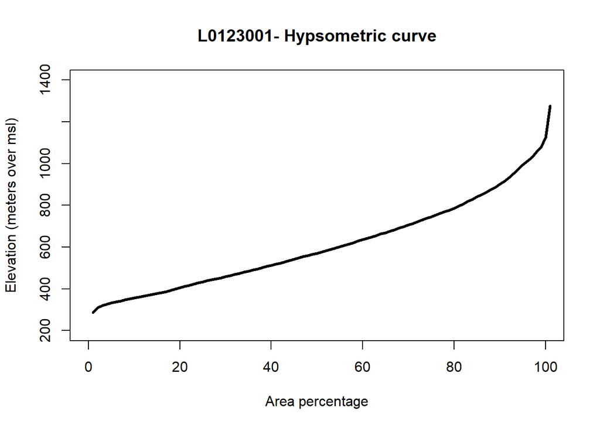

   ```r
   plot(BasinInfo$HypsoData,
        main = "L0123001- Hypsometric curve",
        ylab = "Elevation (meters over msl)",xlab="Area percentage",
        xlim=c(0,100),ylim=c(200,1400),
        type="l", lwd=3)
   ```

   From the above graph, it can be concluded that approximately 50% of the area in the watershed is above 600m above MSL (Mean sea level). From this a hypothesis can be derived that as the heights in the watershed are high, so it could be inferred as a mountainous area.
3. Find the median and maximum elevations for this basin

   ```r
   median(BasinInfo$HypsoData)
   ```

   ```
   ## [1] 577
   ```

   ```r
   max(BasinInfo$HypsoData)
   ```

   ```
   ## [1] 1278
   ```

   The median hereby confirms our inference that 50 % of the land is approximately 600m above MSL.
4. In the rest of the BE, we will consider that it is a low-land basin. **Justify this choice**.

   *We are making this consideration as, if we consider it as high land basin than there is a factor of snow production which can effect the process of surface runoff and discharge in the river.*

## Data description

1. Display the information about the hydrometeorological observed time series in the basin:
   1. Display the internal structure of the data *BasinObs*

   ```r
   str(BasinObs)
   ```

   ```
   ## 'data.frame':    10593 obs. of  6 variables:
   ##  $ DatesR: POSIXct, format: "1984-01-01" "1984-01-02" ...
   ##  $ P     : num  4.1 15.9 0.8 0 0 0 0 0 2.9 0 ...
   ##  $ T     : num  0.5 0.2 0.9 0.5 -1.6 0.9 3.5 4.4 7 6.4 ...
   ##  $ E     : num  0.2 0.2 0.3 0.3 0.1 0.3 0.4 0.4 0.5 0.5 ...
   ##  $ Qls   : int  2640 3440 12200 7600 6250 5650 5300 4700 3940 5300 ...
   ##  $ Qmm   : num  0.634 0.826 2.928 1.824 1.5 ...
   ```

   2. Display the first rows of the dataframe with function *head()*

   ```r
   head(BasinObs)
   ```

   |  | DatesR | P | T | E | Qls | Qmm |
   | --- | --- | --- | --- | --- | --- | --- |
   | 1 | 1984-01-01 | 4.1 | 0.5 | 0.2 | 2640 | 0.6336 |
   | 2 | 1984-01-02 | 15.9 | 0.2 | 0.2 | 3440 | 0.8256 |
   | 3 | 1984-01-03 | 0.8 | 0.9 | 0.3 | 12200 | 2.9280 |
   | 4 | 1984-01-04 | 0.0 | 0.5 | 0.3 | 7600 | 1.8240 |
   | 5 | 1984-01-05 | 0.0 | -1.6 | 0.1 | 6250 | 1.5000 |
   | 6 | 1984-01-06 | 0.0 | 0.9 | 0.3 | 5650 | 1.3560 |

   3. Display the start and end dates of the time series

   ```r
   min(BasinObs$DatesR)
   ```

   ```
   ## [1] "1984-01-01 UTC"
   ```

   ```r
   max(BasinObs$DatesR)
   ```

   ```
   ## [1] "2012-12-31 UTC"
   ```

   Give a brief description of the data.frame :
   - number of variables

   There are **6** Variables in the Data frame.
   - number of observations

   There are **10593** observations in the data frame
   - for each variable : name, type, unit, description

   - for period : time step, first date, last date

     The time step is **daily,** starting from **1984-01-01** till **2012-12-31.**

   Help yourself with the following online section:  
   [<https://cran.r-project.org/web/packages/airGRteaching/vignettes/get_started.html>](https://cran.r-project.org/web/packages/airGRteaching/vignettes/get_started.html)
2. Display the basic statistical values of the data

   ```r
   summary(BasinObs)
   ```

   ```
   ##      DatesR                 P                T                 E
   ##  Min.   :1984-01-01   Min.   : 0.000   Min.   :-18.700   Min.   :0.000
   ##  1st Qu.:1991-04-02   1st Qu.: 0.000   1st Qu.:  4.100   1st Qu.:0.600
   ##  Median :1998-07-02   Median : 0.300   Median :  9.100   Median :1.400
   ##  Mean   :1998-07-02   Mean   : 2.915   Mean   :  9.147   Mean   :1.764
   ##  3rd Qu.:2005-10-01   3rd Qu.: 3.600   3rd Qu.: 14.500   3rd Qu.:2.900
   ##  Max.   :2012-12-31   Max.   :66.800   Max.   : 28.400   Max.   :5.500
   ##
   ##       Qls             Qmm
   ##  Min.   :   70   Min.   : 0.0168
   ##  1st Qu.: 1640   1st Qu.: 0.3936
   ##  Median : 4050   Median : 0.9768
   ##  Mean   : 6130   Mean   : 1.4732
   ##  3rd Qu.: 7850   3rd Qu.: 1.8840
   ##  Max.   :99500   Max.   :23.8800
   ##  NA's   :772     NA's   :802
   ```

   ```r
   QlsperNA <- ((802+772)/10593)*100
   print(QlsperNA)
   ```

   ```
   ## [1] 14.85887
   ```

```r
library(viridis)
```

[figure not shown]

[output not shown]

```r
plot(BasinObs$DatesR, BasinObs$Qls, xlab = 'Years', ylab = 'Qls (m3/sec)', main = "Time Series", lty = 1, cex = 0.50, col = viridis(n=256, option = "D"))
```

3. Calculate the mean precipitation, potential evapotranspiration and flow (in mm), removing the missing values when needed:

   ```r
   Pm=mean(BasinObs$P)
   Em=mean(BasinObs$E)
   Qm=mean(BasinObs$Qmm,na.rm=T)
   print(c(Pm,Em,Qm))
   ```

   ```
   ## [1] 2.914595 1.764099 1.473169
   ```

   Calculate a simple water balance and the runoff coefficient.

   *The law of **water balance** states that the inflows to any water system or area are equal to its outflows plus its change in storage during a time interval.* *The **runoff coefficient** is a dimensionless coefficient relating the amount of runoff to the amount of precipitation received.*

   ```r
   WaterBalance=Pm-Em-Qm
   print(WaterBalance)
   ```

   ```
   ## [1] -0.3226738
   ```

   The negative sign of the water balance shows that the amount of rainfall system received was less than the losses of the system.

   ```r
   RunoffCoeff= Qm/Pm
   print(RunoffCoeff)
   ```

   ```
   ## [1] 0.5054458
   ```

   The runoff coefficient of 0.5 suggest that 50 % of the rainfall that the system receives is converted to flow (Qm). Hence we can say that the response of the system is moderate.

   *NB: To be rigorous, we would have detected the years with too many missing data and eliminated them from the sample. But the idea here is to quickly detect inconsistencies in the data and to evaluate the interest of doing further tests.*

   Write a brief opinion on the consistency of these values.

   From the summary, the opinion deduced regarding the consistency is that, mean and median of temperature and Evapotranspiration values are very close to each other which suggest that there is not that much variation in the data. But if we see the precipitation and discharge data there exist an unavoidable difference between the mean and median which suggest that there exist fluctuation in data, such that they are not consistent.

## Hydrological regime

1. Extract a new vector BasinObsQ containing the observations only for the dates with a discharge value

   ```r
   BasinObsQ<-BasinObs[which(!is.na(BasinObs$Qls)),]
   ```

   ```r
   # BasinObsQ<-BasinObs[is.na(BasinObs$Qls)==...,]
   ```

2. Calculate the average monthly discharge in m3/s

   ```r
   Qmonth<-aggregate(BasinObsQ$Qls/1000, list(format(BasinObsQ$DatesR,"%m")), FUN=mean)
   colnames(Qmonth)<-c("Month","Qm3s")
   summary(Qmonth)
   ```

   ```
   ##     Month                Qm3s
   ##  Length:12          Min.   : 1.311
   ##  Class :character   1st Qu.: 4.077
   ##  Mode  :character   Median : 7.018
   ##                     Mean   : 6.153
   ##                     3rd Qu.: 8.302
   ##                     Max.   :10.849
   ```

3. Plot an histogram of the average monthly discharge

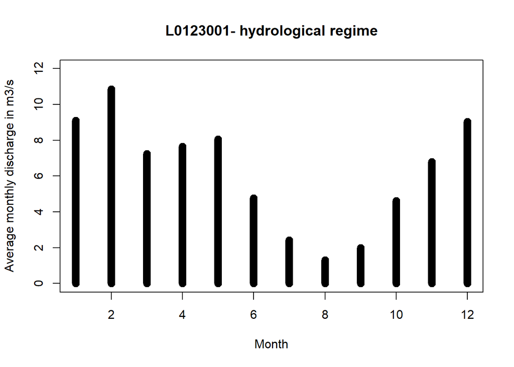

```r
    plot(Qmonth$Qm3s,
         main = "L0123001- hydrological regime",
         ylab = "Average monthly discharge in m3/s",xlab="Month",
         xlim=c(1,12),ylim=c(0,12),
         type="h", lwd=10)
```

From figure above we can see that highest discharge is in the winter months (December to February) and lower are in the summer months (June to August), which is common trend in most of the rivers. This lower discharge could be due to dry soil and due to higher evapotranspiration process, the lower evapotranspiration hypothesis is also due to the negative water balance we achieved. One hypothesis of greater agriculture activity during the summer season could be a factor for lower discharge as initial abstraction increases.

4. Calculate the average monthly precipitation in mm

   ```r
   Psum<-aggregate(BasinObs$P, list(format(BasinObs$DatesR, "%Y-%m")), FUN=sum)
   colnames(Psum)<-c("Date","P")
   Psum$Date <- as.POSIXct(paste(Psum$Date,"01",sep="-")) # paste is used for concatenating/ binding the                                                               strings together" , # if we do not write                                                               as.PosIexct then it wont show it as date
   Pmonth<-aggregate(Psum$P, list(format(Psum$Date,"%m")), FUN=mean)
   summary(Pmonth)
   ```

   ```
   ##    Group.1                x
   ##  Length:12          Min.   : 68.80
   ##  Class :character   1st Qu.: 79.35
   ##  Mode  :character   Median : 85.70
   ##                     Mean   : 88.72
   ##                     3rd Qu.: 96.02
   ##                     Max.   :119.07
   ```

   Plot an histogram of the average monthly precipitation

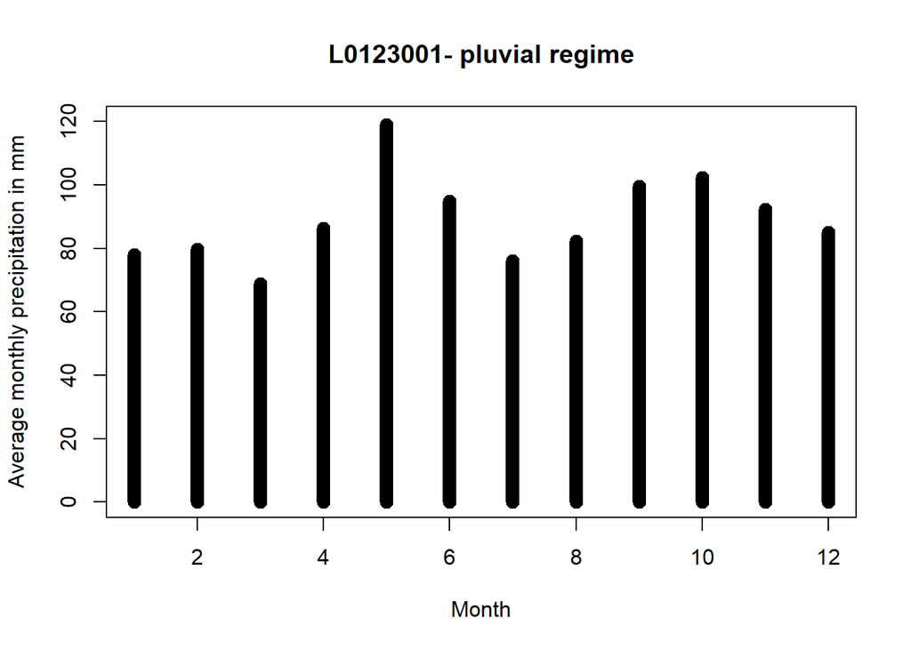

   ```r
   plot(Pmonth,
        main = "L0123001- pluvial regime",
        ylab = "Average monthly precipitation in mm",xlab="Month",
        xlim=c(1,12),ylim=c(0,120),
        type="h", lwd=10)
   ```

## Data preparation

1. Prepare a data.frame for the function “PrepGR”:
   1. Look up the help for function “PrepGR” from the package “airGRteaching” in the console (make sure that the package is loaded in the console).
   2. Prepare a dataframe with the right format (argument obsDF). Select and order columns in a new dataframe named “BasinObs2”

   ```r
   BasinObs2 <- BasinObs[,c("DatesR","P","E","Qmm","T")]
   ```

   3. Use the PrepGR function to select the “GR4J” hydrological model without activating its “Cemaneige” snow module.

   ```r
   PREP <- PrepGR(ObsDF = BasinObs2, HydroModel = "GR4J", CemaNeige = FALSE)
   ```

   4. Check the type of object returned by the function

   ```r
   is(PREP)
   ```

   ```
   ## [1] "PrepGR"
   ```

   ```r
   typeof(PREP)
   ```

   ```
   ## [1] "list"
   ```

   5. Display the internal structure of the object in a compact way

   ```r
   str(PREP)
   ```

   ```
   ## List of 3
   ##  $ InputsModel:List of 3
   ##   ..$ DatesR : POSIXlt[1:10593], format: "1984-01-01" "1984-01-02" ...
   ##   ..$ Precip : num [1:10593] 4.1 15.9 0.8 0 0 0 0 0 2.9 0 ...
   ##   ..$ PotEvap: num [1:10593] 0.2 0.2 0.3 0.3 0.1 0.3 0.4 0.4 0.5 0.5 ...
   ##   ..- attr(*, "class")= chr [1:3] "InputsModel" "daily" "GR"
   ##  $ Qobs       : num [1:10593] 0.634 0.826 2.928 1.824 1.5 ...
   ##  $ TypeModel  : chr "RunModel_GR4J"
   ##  - attr(*, "class")= chr [1:2] "PrepGR" "GR"
   ```

2. Plot a graph with precipitation and flow time series from PREP with main title “L0123001 - Observation”

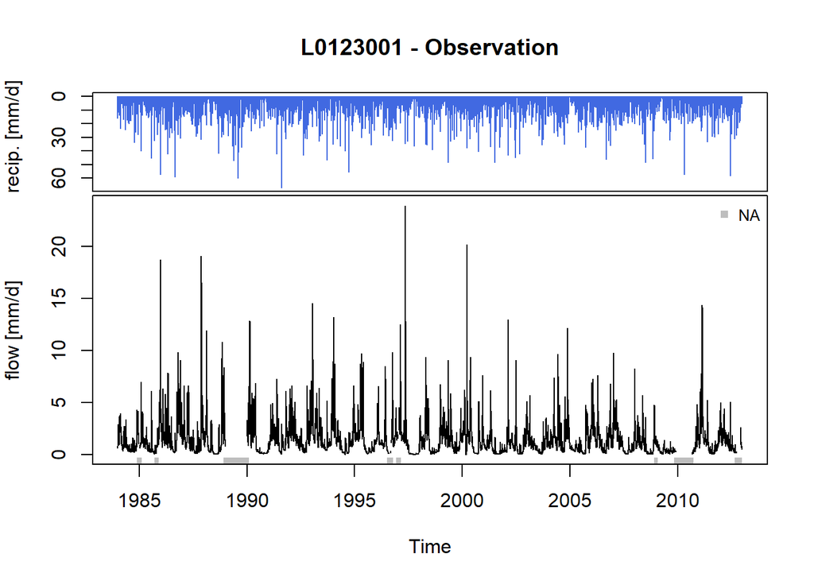

   ```r
   plot(PREP,main="L0123001 - Observation")
   ```

   The above graph plots the precipitation and flow against the time, this temporal distribution allow us to observe the trend of precipitation and discharge with respect to time.

   *NB: By using the airGR object, you are using the plot() function from the airGR package by default.*

# 2 - Graphic user interface (GUI)

*Uncomment/Comment the R code before/after execution of “knit”.*

```r
# ShinyGR(ObsDF = BasinObs2, SimPer = c("1994-01-01", "1998-12-31"),NamesObsBV = "Low-land basin")
```

Your default internet browser should open directly and display the GUI.  
For example:  
—————————  
Loading required package: shiny  
Listening on http://127.0.0.1:5871  
—————————

*Warning: the port number after http://127.0.0.1is different for each session*

Depending on the package version, the interface may be slightly different.  
Now explore the functionality of the interface and calibrate the GR4J model.

To stop the GUI, return to the R console on RStudio and click on the “Stop” button in the top right corner of the frame.

# 3 - Command lines

## Calibrate the model

1. Look up the help for function “CalGR” in the console.
2. Use the CalGR function and select the Nash-Sutcliffe Efficiency (NSE) criterion, the default warmup period and a calibration period from 01/01/1994 to 31/12/1998.

   ```r
   CAL <- CalGR(PrepGR = PREP, CalCrit = "NSE", WupPer = NULL, CalPer = c("1994-01-01", "1998-12-31"))
   ```

   ```
   ## Grid-Screening in progress (0% 20% 40% 60% 80% 100%)
   ##   Screening completed (81 runs)
   ##       Param =  169.017,   -0.020,   83.096,    2.384
   ##       Crit. NSE[Q]       = 0.7912
   ## Steepest-descent local search in progress
   ##   Calibration completed (22 iterations, 242 runs)
   ##       Param =  249.635,    0.956,   76.708,    2.247
   ##       Crit. NSE[Q]       = 0.8150
   ```

   check the type of object returned by the function

   ```r
   is(CAL)
   ```

   ```
   ## [1] "CalGR"
   ```

   ```r
   typeof(CAL)
   ```

   ```
   ## [1] "list"
   ```

   Display the internal structure of the object in a compact way

   ```r
   str(CAL)
   ```

   ```
   ## List of 7
   ##  $ OptionsCalib:List of 8
   ##   ..$ IndPeriod_WarmUp: int [1:365] 3289 3290 3291 3292 3293 3294 3295 3296 3297 3298 ...
   ##   ..$ IndPeriod_Run   : int [1:1826] 3654 3655 3656 3657 3658 3659 3660 3661 3662 3663 ...
   ##   ..$ IniStates       : num [1:67] 0 0 0 0 0 0 0 0 0 0 ...
   ##   ..$ IniResLevels    : num [1:4] 0.3 0.5 NA NA
   ##   ..$ Outputs_Cal     : chr [1:2] "Qsim" "Param"
   ##   ..$ Outputs_Sim     : Named chr [1:22] "DatesR" "PotEvap" "Precip" "Prod" ...
   ##   .. ..- attr(*, "names")= chr [1:22] "" "GR1" "GR2" "GR3" ...
   ##   ..$ FortranOutputs  :List of 2
   ##   .. ..$ GR: chr [1:18] "PotEvap" "Precip" "Prod" "Pn" ...
   ##   .. ..$ CN: NULL
   ##   ..$ FeatFUN_MOD     :List of 12
   ##   .. ..$ CodeMod     : chr "GR4J"
   ##   .. ..$ NameMod     : chr "GR4J"
   ##   .. ..$ NbParam     : int 4
   ##   .. ..$ TimeUnit    : chr "daily"
   ##   .. ..$ Id          : logi NA
   ##   .. ..$ Class       : chr [1:2] "daily" "GR"
   ##   .. ..$ Pkg         : chr "airGR"
   ##   .. ..$ NameFunMod  : chr "RunModel_GR4J"
   ##   .. ..$ TimeStep    : num 86400
   ##   .. ..$ TimeStepMean: int 86400
   ##   .. ..$ CodeModHydro: chr "GR4J"
   ##   .. ..$ IsSD        : logi FALSE
   ##   ..- attr(*, "class")= chr [1:3] "RunOptions" "daily" "GR"
   ##  $ Qobs        : num [1:1826] 2.9 2.83 2.36 2.54 2.64 ...
   ##  $ OutputsCalib:List of 9
   ##   ..$ ParamFinalR  : num [1:4] 249.635 0.956 76.708 2.247
   ##   ..$ CritFinal    : num 0.815
   ##   ..$ NIter        : num 22
   ##   ..$ NRuns        : num 242
   ##   ..$ HistParamR   : num [1:22, 1:4] 169 169 169 233 233 ...
   ##   .. ..- attr(*, "dimnames")=List of 2
   ##   .. .. ..$ : NULL
   ##   .. .. ..$ : chr [1:4] "Param1" "Param2" "Param3" "Param4"
   ##   ..$ HistCrit     : num [1:22, 1] 0.791 0.805 0.805 0.809 0.812 ...
   ##   ..$ MatBoolCrit  : logi [1:1826, 1:2] TRUE TRUE TRUE TRUE TRUE TRUE ...
   ##   .. ..- attr(*, "dimnames")=List of 2
   ##   .. .. ..$ : NULL
   ```

   [output cut: 34 more lines]

   ```
   ##   .. .. ..$ UH1: num [1:20] 0.806 1.43 0.524 0 0 ...
   ##   .. .. ..$ UH2: num [1:40] 0.10461 0.11506 0.11501 0.03969 0.00261 ...
   ##   .. ..$ CemaNeigeLayers:List of 4
   ##   .. .. ..$ G      : num NA
   ##   .. .. ..$ eTG    : num NA
   ##   .. .. ..$ Gthr   : num NA
   ##   .. .. ..$ Glocmax: num NA
   ##   .. ..- attr(*, "class")= chr [1:3] "IniStates" "daily" "GR"
   ##   ..- attr(*, "class")= chr [1:3] "OutputsModel" "daily" "GR"
   ##  $ TypeModel   : chr "RunModel_GR4J"
   ##  $ CalCrit     : chr "ErrorCrit_NSE"
   ##  $ PeriodModel :List of 2
   ##   ..$ WarmUp: POSIXct[1:2], format: "1993-01-01" "1993-12-31"
   ##   ..$ Run   : POSIXct[1:2], format: "1994-01-01" "1998-12-31"
   ##  - attr(*, "class")= chr [1:2] "CalGR" "GR"
   ```

3. Look at the performance of the calibration. Find in the ‘OutputsCalib’ attribute the type of criterion and its final value, the number of iteration and the final set of parameter values

   ```r
   CAL$OutputsCalib$CritName
   ```

   ```
   ## [1] "NSE[Q]"
   ```

   ```r
   CAL$OutputsCalib$CritFinal
   ```

   ```
   ## [1] 0.8150063
   ```

   ```r
   CAL$OutputsCalib$NIter
   ```

   ```
   ## [1] 22
   ```

   ```r
   CAL$OutputsCalib$ParamFinalR
   ```

   ```
   ## [1] 249.635037   0.956116  76.707539   2.246997
   ```

   | X1 | X2 | X3 | X4 |
   | --- | --- | --- | --- |
   | 249.635037 | 0.956116 | 76.707539 | 2.246997 |

5. Assess the calibration process by plotting relevant graphs:
   1. Plot the performance graph

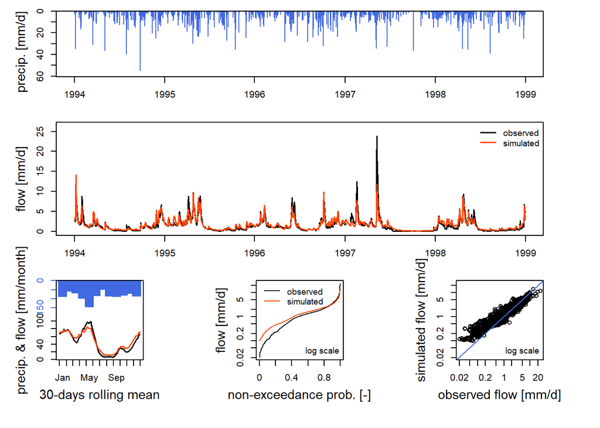

   ```r
   plot(CAL, which = "perf")
   ```

   2. Plot the iteration graph

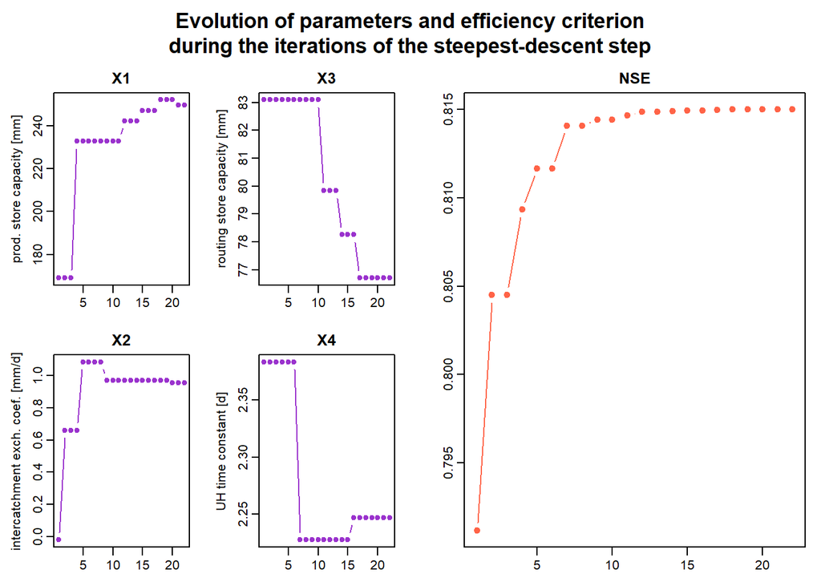

   ```r
   plot(CAL, which = "iter")
   ```

## Simulate a period

1. Look up the help for function “SimGR” in the console and see the different arguments.
2. Use SimGR with the calibrated model and define the simulation period from 01/01/1999 to 31/12/2000, the default warmup period and choose the NSE criterion to evaluate the quality of the simulation.

   ```r
   SIM <- SimGR(PrepGR = PREP , CalGR = CAL, EffCrit = "NSE", WupPer = NULL,
   SimPer = c("1999-01-01", "2000-12-31"))
   ```

   ```
   ## Crit. NSE[Q] = 0.7731
   ```

   Check the type of object returned by the function

   ```r
   is(SIM)
   ```

   ```
   ## [1] "SimGR"
   ```

   ```r
   typeof(SIM)
   ```

   ```
   ## [1] "list"
   ```

   Display the internal structure of the object in a compact way

   ```r
   str(SIM)
   ```

   ```
   ## List of 8
   ##  $ OptionsSimul:List of 8
   ##   ..$ IndPeriod_WarmUp: int [1:365] 5115 5116 5117 5118 5119 5120 5121 5122 5123 5124 ...
   ##   ..$ IndPeriod_Run   : int [1:731] 5480 5481 5482 5483 5484 5485 5486 5487 5488 5489 ...
   ##   ..$ IniStates       : num [1:67] 0 0 0 0 0 0 0 0 0 0 ...
   ##   ..$ IniResLevels    : num [1:4] 0.3 0.5 NA NA
   ##   ..$ Outputs_Cal     : chr [1:2] "Qsim" "Param"
   ##   ..$ Outputs_Sim     : Named chr [1:22] "DatesR" "PotEvap" "Precip" "Prod" ...
   ##   .. ..- attr(*, "names")= chr [1:22] "" "GR1" "GR2" "GR3" ...
   ##   ..$ FortranOutputs  :List of 2
   ##   .. ..$ GR: chr [1:18] "PotEvap" "Precip" "Prod" "Pn" ...
   ##   .. ..$ CN: NULL
   ##   ..$ FeatFUN_MOD     :List of 12
   ##   .. ..$ CodeMod     : chr "GR4J"
   ##   .. ..$ NameMod     : chr "GR4J"
   ##   .. ..$ NbParam     : int 4
   ##   .. ..$ TimeUnit    : chr "daily"
   ##   .. ..$ Id          : logi NA
   ##   .. ..$ Class       : chr [1:2] "daily" "GR"
   ##   .. ..$ Pkg         : chr "airGR"
   ##   .. ..$ NameFunMod  : chr "RunModel_GR4J"
   ##   .. ..$ TimeStep    : num 86400
   ##   .. ..$ TimeStepMean: int 86400
   ##   .. ..$ CodeModHydro: chr "GR4J"
   ##   .. ..$ IsSD        : logi FALSE
   ##   ..- attr(*, "class")= chr [1:3] "RunOptions" "daily" "GR"
   ##  $ OptionsCrit :List of 8
   ##   ..$ FUN_CRIT:function (InputsCrit, OutputsModel, warnings = TRUE, verbose = TRUE)
   ##   .. ..- attr(*, "class")= chr [1:2] "FUN_CRIT" "function"
   ##   ..$ Obs     : num [1:731] 4.01 4.27 4.97 4.39 3.82 ...
   ##   ..$ VarObs  : chr "Q"
   ##   ..$ BoolCrit: logi [1:731] TRUE TRUE TRUE TRUE TRUE TRUE ...
   ##   ..$ idLayer : logi NA
   ##   ..$ transfo : chr ""
   ##   ..$ epsilon : NULL
   ##   ..$ Weights : NULL
   ##   ..- attr(*, "class")= chr [1:2] "Single" "InputsCrit"
   ##  $ OutputsModel:List of 21
   ##   ..$ DatesR    : POSIXlt[1:731], format: "1999-01-01" "1999-01-02" ...
   ##   ..$ PotEvap   : num [1:731] 0.6 0.4 0.2 0.1 0.3 0.3 0.1 0 0.1 0.2 ...
   ```

   [output cut: 35 more lines]

   ```
   ##   ..- attr(*, "class")= chr [1:3] "OutputsModel" "daily" "GR"
   ##  $ Qobs        : num [1:731] 4.01 4.27 4.97 4.39 3.82 ...
   ##  $ TypeModel   : chr "RunModel_GR4J"
   ##  $ CalCrit     : chr "ErrorCrit_NSE"
   ##  $ EffCrit     :List of 5
   ##   ..$ CritValue      : num 0.773
   ##   ..$ CritName       : chr "NSE[Q]"
   ##   ..$ CritBestValue  : num 1
   ##   ..$ Multiplier     : num -1
   ##   ..$ Ind_notcomputed: NULL
   ##   ..- attr(*, "class")= chr [1:2] "NSE" "ErrorCrit"
   ##  $ PeriodModel :List of 2
   ##   ..$ WarmUp: POSIXct[1:2], format: "1998-01-01" "1998-12-31"
   ##   ..$ Run   : POSIXct[1:2], format: "1999-01-01" "2000-12-31"
   ##  - attr(*, "class")= chr [1:2] "SimGR" "GR"
   ```

3. Look at the performance of the simulation. Identify with the ‘EffCrit’ attribute the criterion used to evaluate the simulation and its value

   ```r
   SIM$EffCrit$CritName
   ```

   ```
   ## [1] "NSE[Q]"
   ```

   ```r
   SIM$EffCrit$CritValue
   ```

   ```
   ## [1] 0.7730962
   ```

The Qsim obtained from the SimGR function is less robust than the Qsim obtain from the CalGR, the reason for this is based on the NSE [Q] values, as for the former case [SImGR] it is 77 % while for the later case [CalGR] it is 81.5 %

4. Plot graphs to perform a diagnostic of the simulation:
   1. Plot a static graph:

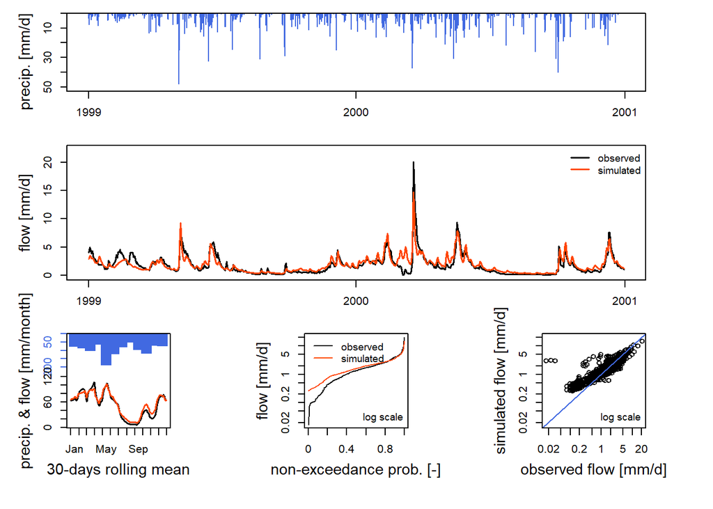

   ```r
   plot(SIM)
   ```

   2. Plot a dynamic graph with main title ‘Simulation’  
      *Uncomment/Comment the line before/after execution to “knit” the file.*

   ```r
   dyplot(SIM, main = "Simulation")
   ```

[interactive chart not shown]

From the performance graph we observe that the discharge time series, visually looks like the simulated flow superimposes the observed flow. Also the rolling mean graphs illustrates that for both simulated and observed series follow the same trend, which is higher flows in winter and low flows in summer. The graph between non-exceedance probability and flow for both the simulated and observed series is almost similar for higher values of flow while for lower values of flow the exceedance probability for both the series differ. But if we compare the performance graph of SimGR function and CalGR function, the later one gives more robust results.

# 4- Hydrological model type

*This part is necessary for the BE but can be done at home before the second session.*

The model used for these two work sessions is the GR4J model. This model is part of a series of models developed by INRAE: https://webgr.inrae.fr/en/models/

Read the description of the GR4J model:

https://webgr.inrae.fr/en/models/daily-hydrological-model-gr4j/  
https://webgr.inrae.fr/en/models/daily-hydrological-model-gr4j/description-of-the-gr4j-model/

Identify:

- its time-step, the necessary input data and the output data

  The GR4J model is a daily time-step model

  The input data are the precipition and the potential evapotranspiration

  The output data is total streamflow
- its spatial structure (global, semi-distributed or distributed)

  The model is a global spatial structure
- its way of representing hydrological processes (conceptual mode or physical equation)

  It is a conceptual model
- its way of representing basin structure (conceptual reservoirs or physical layers)

  It represent a conceptual reservoirs basin structure.
- its number of parameters to calibrate and their definition

  X1: the production store maximal capacity (mm),

  X2: the catchment water exchange coefficient (mm/day),

  X3: the one-day maximal capacity of the routing reservoir (mm),

  X4: the HU1 unit hydro graph time base (days).

Write a brief description of the model and insert its diagram.

GR4J is a conceptual water balance model which means it defines the conceptual phenomenon that how rainfall and runoff occurs but it does not define the physical process by using any physical equations. It relates runoff to rainfall and evapotranspiration using daily data. The inputs to the model are precipitation and potential evaporation and gives discharge as the output. It uses a global spatial structure i.e like a lumped model and the limitation of this consideration is that it cannot take into account heterogeneity. It is based on two reservoir model with 4 following parameters.

X1: the production store maximal capacity (mm),

X2: the catchment water exchange coefficient (mm/day),

X3: the one-day maximal capacity of the routing reservoir (mm),

X4: the HU1 unit hydro graph time base (days)

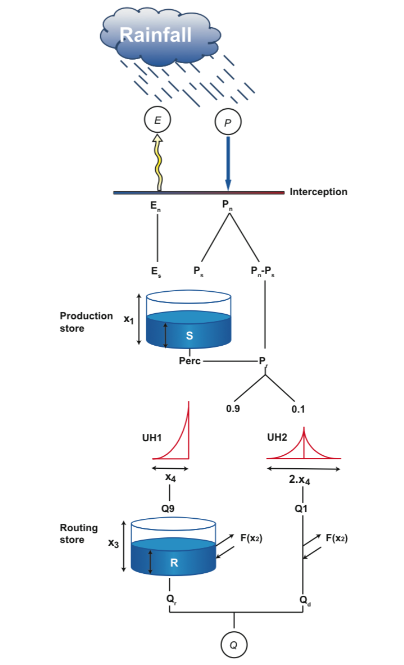